# Biblioteki - notatki

# viridis

Biblioteka w Pythonie *Matplotlib* wprowadziła ostatnio nowe standardy kolorów map - nazwane viridis, magma, inferno i plasma. Viridis stał się nową standardową mapą kolorów Matplotlibu. Mapy zostały tak zaprojektowane, że mogą być poprawnie postrzegane przez daltonistów, a także wydrukowane na biało-czarno.

```r
#install.packages("viridis")
library(viridis)
```

Żeby użyć skali viridis w ggplot używamy scale_fill_viridis() albo scale_color_viridis(). Można także jako argument w tych funkcjach podać inną skalę wyżej wymienioną, np.: scale_fill_virdis(option=“magma”). Może być także używana w przypadku zmiennej dyskretnej, np.: scale_color_viridis(discrete=T)

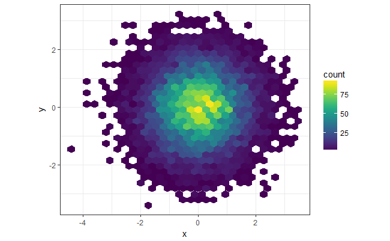

```r
#install.packages("hexbin")
library(hexbin)
library(ggplot2)
ggplot(data.frame(x = rnorm(10000), y = rnorm(10000)), aes(x = x, y = y)) +
  geom_hex() + coord_fixed() +
  scale_fill_viridis() + theme_bw()
```

Funkcja viridis() generuje wektor kolorów z mapy kolorów virdis

```r
viridis(n=10, alpha=1, option="D")
```

```
 [1] "#440154FF" "#482878FF" "#3E4A89FF" "#31688EFF" "#26828EFF" "#1F9E89FF" "#35B779FF" "#6DCD59FF" "#B4DE2CFF"
[10] "#FDE725FF"
```

option:

- “A”=“magma”
- “B”=“inferno”
- “C”=“plasma”
- “D”=“viridis”

Fukcja viridis_pal() tworzy dyskretną paletę kolorów z viridis. Poniżej fajny kawałek kodu do wizualizacji wygenerowanych kolorów

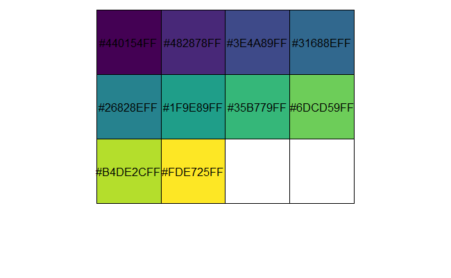

```r
library(scales)
show_col(viridis_pal()(10))
```

Zwróć uwagę na dziwne wywowałenie tej funkcji.

Należy też zauważyć, że ten sam output daje viridis_pal()(10) jak i viridis(10).

# permute

Do sprawdzania, czy rozkłady, z których pochodzą próby, są takie same, stosuje się rozmaite testy statystyczne. Zawsze polegają one na obliczeniu pewnej funkcji, zwanej statystyką testową, której argumentem są zadane próby. Wynik tej funkcji z pomocą tablic (a corazcczęściej komputera) przekształca się na p-wartość, która porównana z założonym poziomem istotności pozwala nam stwierdzić istnienie lub brak przesłanek do podważenia prawdziwości hipotezy o równości rozkładów.

Niestety bardzo często (np. w przypadku testu t-Studenta) ich teoretyczne podstawy wymagają dodatkowych założeń o porównywanych rozkładach (np. o normalności rozkładów). Bez tych założeń nie wiedzielibyśmy jaki jest rozkład statystki testowej, a więc i p-wartości uzyskane byłyby w sposób heurystyczny, bez dowodu, że są one poprawne. Niestety w praktyce nie zawsze można formalnie sprawdzić czy zachodzą wymagane założenia o rozkładach.

Okazuje się jednak, że zamiast wielu testów możemy zastosować odpowiadające im te- sty permutacyjne, które nie wymagają dodatkowych założeń o rozkładach porównywanych prób. Testy te opierają się na spostrzeżeniu, że jeżeli hipoteza zerowa o równości rozkładów jest prawdziwa, to zamiast naszych dwóch prób mogliśmy, z takim samym prawdopodobień- stwem, zobaczyć obserwacje o tych samych wartościach, ale innym podziałem na próby. Dla przykładu, gdy naszą obserwacją są dwie dwuelementowe próby: ({0,2,0,37},{0,11,0,29}), i zakładamy, że pochodzą z takich samych rozkładów, to równie prawdopodobne było zaob- serwowanie prób ({0,2,0,29},{0,11,0,37}), czy też ({0,11,0,2},{0,29,0,37}). Powyższe spostrzeżenie pozwala znaleźć rozkład statystki testowej, na podstawie wartości uzyskanych przez tę funkcję przy różnych podziałach na próby. Dzięki temu możemy obliczyć p-wartość i dalej postępować tak, jak w przypadku innych testów statystycznych.

**Randomizacja** jest to losowy dobór osób do badania. Losowość należy tutaj rozumieć, że każdy przypadek z badanej populacji ma taką samą szansę być uczestnikiem badania co każdy inny. Stosując odpowiednie metody losowania badacze “dają” szansę każdej osobie zpopulacji na bycie osobą badaną.

Powody stosowania randomizacji w badaniach to:

1. zminimalizowanie wpływu zmiennych niekontrolowanych. Stosując losowość doboru osób do badania minimalizuje się wpływ niekontrolowanych czynników.
2. odzwierciedlenie charakterystyki populacji (np. Polacy) w badanej próbie (np. 1000 osób)
3. uprawdopodobnienie otrzymanych rezultatów badań

A permutation-based test can be used to test the same Null hypothesis, but without some of the assumptions of the t test, most importantly the assumption that the data are a random sample from the population of golden jackals. With a permutation test, we are free to choose any suitable test statistic

Biblioteka permute pozwala na dokonywanie testów permutacyjnych. Najważniejsza funkcja to shuffle(), która jest jakby wrapem funkcji sample(). Dostępny jest argument *control*, w którym definiujemy jak mają być dokonane permutacje.

```r
library(permute)
set.seed(2)
shuffle(10)
```

[1] 2 7 5 10 6 8 1 3 4 9

```r
set.seed(2)
sample(1:10,10,replace=F)
```

[1] 2 7 5 10 6 8 1 3 4 9

Przykład wykorzystania funkcji shuffle() do zbadania rowności średnich w dwóch grupach na podstawie zbioru dostępnego w bibliotece permute.

```r
Djackal <- numeric(length = 5000)
data(jackal)
N <- nrow(jackal)
#funkcja do liczenia roznic srednich
meanDif <- function(x, grp) {
    mean(x[grp == "Male"]) - mean(x[grp == "Female"])
}
#dla roznych kombinacji liczy roznice srednich
set.seed(42)
for (i in seq_len(length(Djackal) - 1)) {
   perm <- shuffle(N)
   Djackal[i] <- with(jackal, meanDif(Length, Sex[perm]))
}
#ostatnim elementem jest zaobserwowana na zbiorze roznica srednich
Djackal[5000] <- with(jackal, meanDif(Length, Sex))
#ile roznic jest wiekszych niz zaobserwowana
Dbig <- sum(Djackal >= Djackal[5000])
# p-value
Dbig/length(Djackal)
```

[1] 0.0024

allPerms() dokonuje wszystkich możliwych permutacji.

```r
wektor<-c(1,2,3)
allPerms(wektor)
```

[output not shown]

```r
allPerms(3)
```

[output not shown]

numPerms() zwraca liczbę możliwych permutacji na danym obiekcie.